## Setting Global Options

```r
knitr::opts_chunk$set(fig.path = "figure/")
library(markdown)
```

## Loading and preprocessing the data

```r
activity <- read.csv("C:/Users/mahendra.payaal/Documents/coursera/data/activity.csv",stringsAsFactors = FALSE)
activity  <- transform( activity, date = as.Date(date,"%Y-%m-%d"))
```

## What is mean total number of steps taken per day?

### Total number of steps taken everyday

```r
steps_daily_Total <- as.data.frame(with(activity,tapply(steps,date,sum,na.rm=TRUE)))
rownames(steps_daily_Total) <-c(1:61)
colnames(steps_daily_Total) <- "Daily_Steps_Sum"
steps_daily_Total
```

```
##    Daily_Steps_Sum
## 1                0
## 2              126
## 3            11352
## 4            12116
## 5            13294
## 6            15420
## 7            11015
## 8                0
## 9            12811
## 10            9900
## 11           10304
## 12           17382
## 13           12426
## 14           15098
```

[output cut: 47 more lines]

### Histogram of the total number of steps taken each day

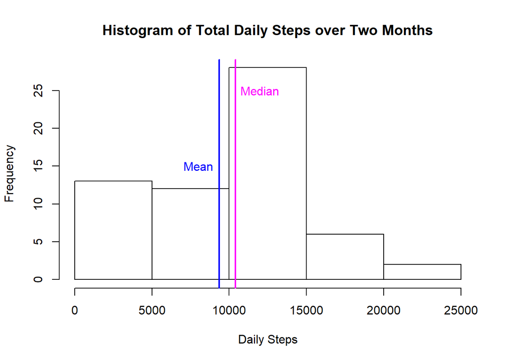

```r
hist(steps_daily_Total$Daily_Steps_Sum,main ="Histogram of Total Daily Steps over Two Months", xlab = "Daily Steps")
abline(v=mean(steps_daily_Total$Daily_Steps_Sum,na.rm = TRUE),lwd =2,col="blue")
text(8000,15,"Mean",col="blue")

abline(v=median(steps_daily_Total$Daily_Steps_Sum,na.rm = TRUE),lwd =2,col="magenta")
text(12000,25,"Median",col="magenta")
```

### Mean total number of steps taken per day

```r
mean_daily <- mean(steps_daily_Total$Daily_Steps_Sum,na.rm = TRUE)
```

```
  The mean of total daily steps is 9354.2295082
```

### Median of total daily steps

```r
median_daily <- median(steps_daily_Total$Daily_Steps_Sum)
```

```
   The median of total daily steps is 10395
```

## What is the average daily activity pattern?

### Time series plot of the average number of steps taken

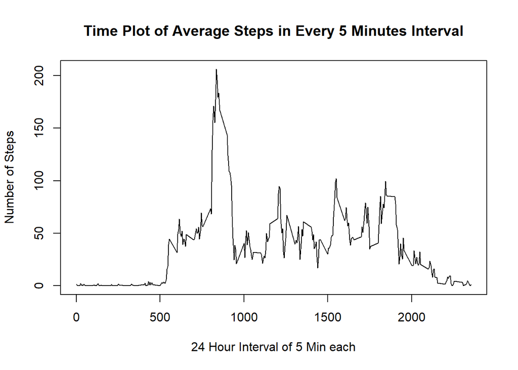

```r
steps_interval_Average <- as.data.frame(with(activity,tapply(steps,interval,mean,na.rm=TRUE)))
names(steps_interval_Average) <- "Average_steps"
plot(as.numeric(rownames(steps_interval_Average)),steps_interval_Average$Average_steps,type ="l",xlab="24 Hour Interval of 5 Min each",ylab="Number of Steps")
title("Time Plot of Average Steps in Every 5 Minutes Interval")
```

### The 5-minute interval that, on average, contains the maximum number of steps

```r
max_interval <- which.max(steps_interval_Average[,1])
names_interval <- rownames(steps_interval_Average)
max_interval<-names_interval[104]
max_int <- sub("(\\d+)(\\d{2})","\\1:\\2",max_interval)
```

```
  The average maximun  steps are in 5 minute interval from 8:35
```

## Imputing missing values

### Total number of missing values

```r
total_NA <- sum(is.na(activity$steps))
```

```
   The total NAs in data frame  are 2304
```

### Code to describe and show a strategy for imputing missing data and creating a new dataset

- ‘NA’ values are replaced by the average values for that time interval. The steps are given below
- A vector“avg_steps” is created which has average value of all intervals
- This vector is replicated 61 times to become equal to rows of “activity” dataframe
- A new data set “activity_new” is created
- Through a ‘For’ loop ‘NA’ values are replaced by average values of that interval

```r
avg_steps <- steps_interval_Average[,1]
avg_steps <- c(rep(avg_steps,times =61))
activity_new <- activity
for (i in 1:nrow(activity_new)) {
      if(is.na(activity_new$steps[i])){
                activity_new$steps[i] <- avg_steps[i]
                 }
}
steps_daily_Total_new <- as.data.frame(with(activity_new,tapply(steps,date,sum,na.rm=TRUE)))
rownames(steps_daily_Total_new) <-c(1:61)
colnames(steps_daily_Total_new) <- "Daily_Steps_Sum"
```

### Histogram of the total number of steps taken each day after missing values are imputed

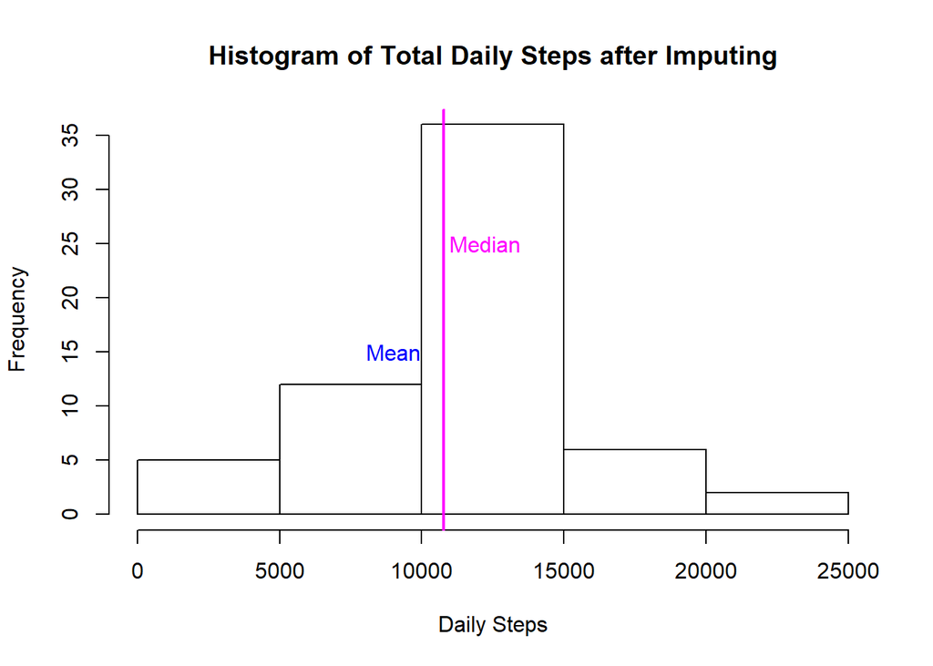

```r
hist(steps_daily_Total_new$Daily_Steps_Sum,main ="Histogram of Total Daily Steps after Imputing", xlab = "Daily Steps")
abline(v=mean(steps_daily_Total_new$Daily_Steps_Sum,na.rm = TRUE),lwd =2,col="blue")
text(9000,15,"Mean",col="blue")
text(12225,25,"Median",col="magenta")
abline(v=median(steps_daily_Total_new$Daily_Steps_Sum,na.rm = TRUE),lwd =2,col="magenta")
```

### Mean of total number of steps taken per day after imputing

```r
mean_daily_imputed <-mean(steps_daily_Total_new$Daily_Steps_Sum,na.rm = TRUE)
```

[output not shown]

### Median of total number of steps taken per day after imputing

```r
median_daily_imputed <- median(steps_daily_Total_new$Daily_Steps_Sum)
```

[output not shown]

## Are there differences in activity patterns between weekdays and weekends?

### Creating a new factor variable based on weekday and weekend

- The ‘date’ variable of “activity_new” dataframe has been identified as “weekday” and “weekend”
- The date variable is replaced with “weekday” or “weekend”
- Two subsets of new dataset -“activity_new”, are created based on “weekday” and “weekend”
- Average is taken by “tapply” across all intervals for the days for two subsets

```r
wday <- weekdays(activity_new$date)
for( i in 1:17568) {
    if(wday[i] =="Saturday"|wday[i]=="Sunday"){
         wday[i] <-"weekend"
    }
  else {wday[i] <-"weekday" }

}
activity_new$date <- wday
weekday_steps <- subset(activity_new,date=="weekday")
weekend_steps <- subset(activity_new,date=="weekend")
steps__weekday <- as.data.frame(with(weekday_steps,tapply(steps,interval,mean,na.rm=TRUE)))
steps__weekend <- as.data.frame(with(weekend_steps,tapply(steps,interval,mean,na.rm=TRUE)))
names(steps__weekday) <- "Average_steps"
names(steps__weekend) <- "Average_steps"
```

### Panel plot comparing the average number of steps taken per 5-minute interval across weekdays and weekends

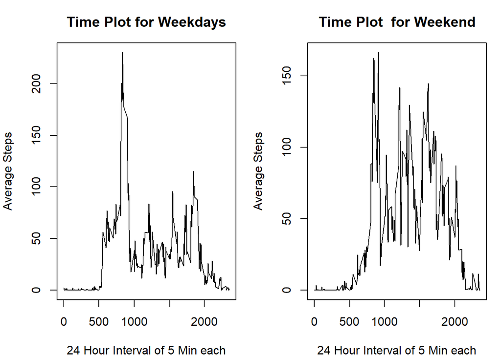

```r
par(mfrow=c(1,2),mar=c(4,4,3,1))
plot(as.numeric(rownames(steps__weekday)),steps__weekday$Average_steps,type ="l",xlab="24 Hour Interval of 5 Min each",ylab="Average Steps")
title("Time Plot for Weekdays")

plot(as.numeric(rownames(steps__weekend)),steps__weekend$Average_steps,type ="l",xlab="24 Hour Interval of 5 Min each",ylab="Average Steps",xlim =c(0000,2359))
title("Time Plot  for Weekend")
```